# Nepal

Early Warning Module

**Summary**

# Sampling

The survey was conducted by the Nepal Red Cross Society (NRCS) as part of the Community Trust Index – Early Warning System module. Data collection was carried out by NRCS volunteers using a standardized questionnaire, with a focus on issues of trust within the framework of the Building Trust initiative.

NRCS implemented three survey waves. The first two waves were conducted between April and May 2025 across selected districts in the western provinces and the Kathmandu Valley. A third wave was later carried out in March 2026 in the Eastern Province (Koshi).

In total, the survey reached 5,309 respondents, of whom 4,958 met the eligibility criteria.

*See metrics: Metrics*

## Geographic

The sample distribution shows some differences compared to the population structure across the surveyed districts. Kathmandu is notably under-represented in the sample (21.2% vs. 29.9%), while Morang (19.2% vs. 10.9%) and Sunsari (14.7% vs. 8.6%) are over-represented relative to official population figures. Other districts show smaller deviations: Kailali is slightly under-represented (12.2% vs. 13.2%), while Banke, Bardiya, Bhaktapur, Kanchanpur, and Lalitpur are all marginally under-represented compared to their population shares.

These differences will be taken into account during the analysis, and weighting or other adjustments may be applied to ensure that the results remain representative.

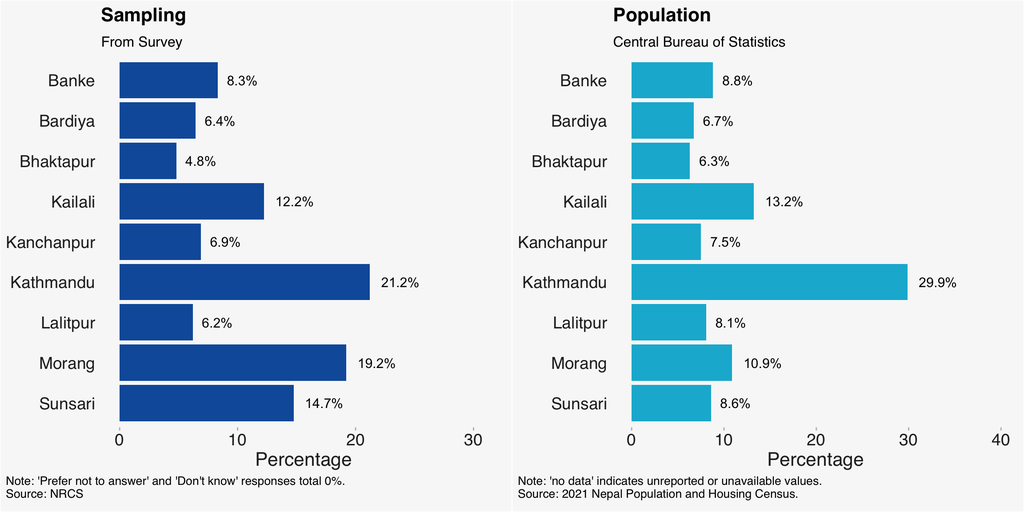

## Coverage

[interactive chart not shown]

## Gender and Age

The sample broadly reflects the population distribution by age and gender, with only minor differences. Among women, age groups closely match the population, although women aged 60+ are slightly under-represented. Among men, those aged 40–59 are somewhat over-represented, while men aged 18–39 are slightly under-represented. Overall, these differences are small and will be considered in the analysis, with adjustments applied if needed to improve representativeness.

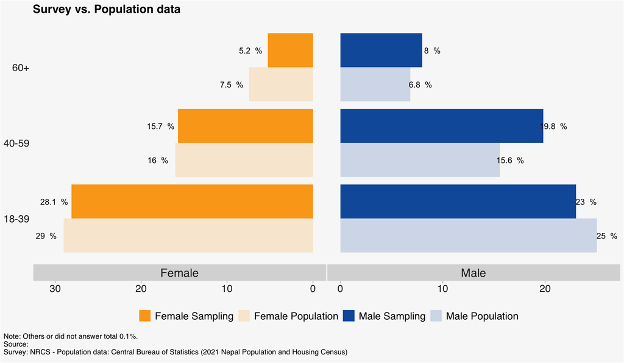

## Education

The sample broadly reflects the population distribution by education level, with some differences across categories. Secondary school education remains the largest group, though it is slightly lower in the sample (39.5% vs. 42.2%). Respondents with primary education (27.5% vs. 22.5%) and no formal education (16.0% vs. 9.7%) are somewhat over-represented, while university-educated respondents are under-represented (17.1% vs. 25.6%). These differences will be considered in the analysis, with adjustments applied if needed to improve representativeness.

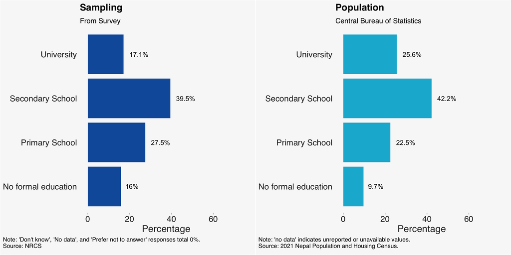

## Employment

The sample differs more noticeably from the population distribution in economic activity status. Employed respondents are substantially over-represented in the sample (67.4% vs. 42.9%), while those who are not economically active (17.8% vs. 34.3%) and not usually active (7.5% vs. 19.4%) are under-represented. Respondents who are active but unemployed are slightly over-represented (7.2% vs. 3.2%). These differences will be considered in the analysis, with adjustments applied where necessary to improve representativeness.

Source: https://censusnepal.cbs.gov.np/results/files/result-folder/Labour%20Force%20and%20Economic%20Activities%20in%20Nepal.pdf

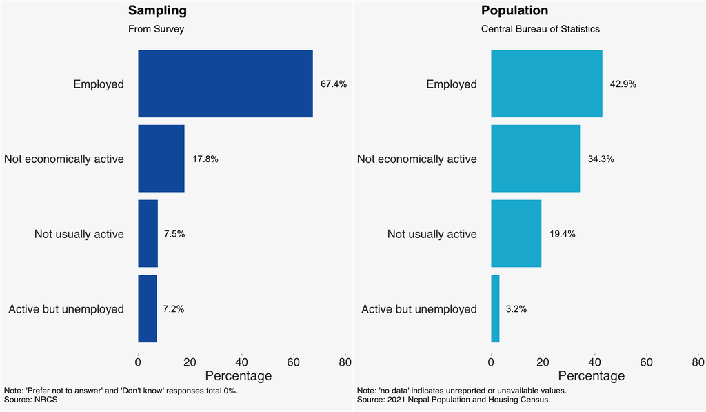

## Limitations

The survey findings should be interpreted with caution due to some differences between the sample and population distribution:

- Age and gender: Men aged 40–59 are over-represented, while younger men and women aged 60+ are slightly under-represented.
- Education: No formal and primary education groups are over-represented, while university-educated respondents are under-represented.
- Employment: Employed respondents are over-represented, while economically inactive groups are under-represented.
- Geography: Some regional and district-level differences remain.

Post-stratification adjustments were applied to improve representativeness; however, some sampling bias may remain, and findings should be considered broadly indicative rather than fully representative. ————————————————————————

# Survey Results

## Drivers of trust

### Pillar 1

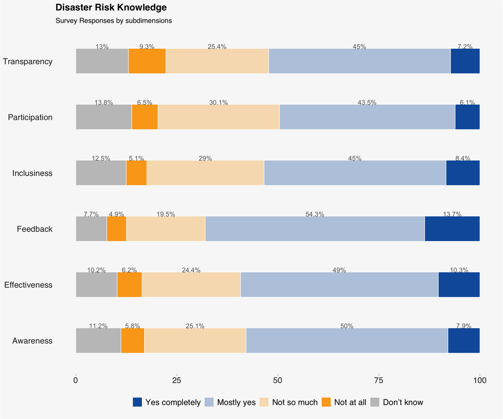

### Pillar 2

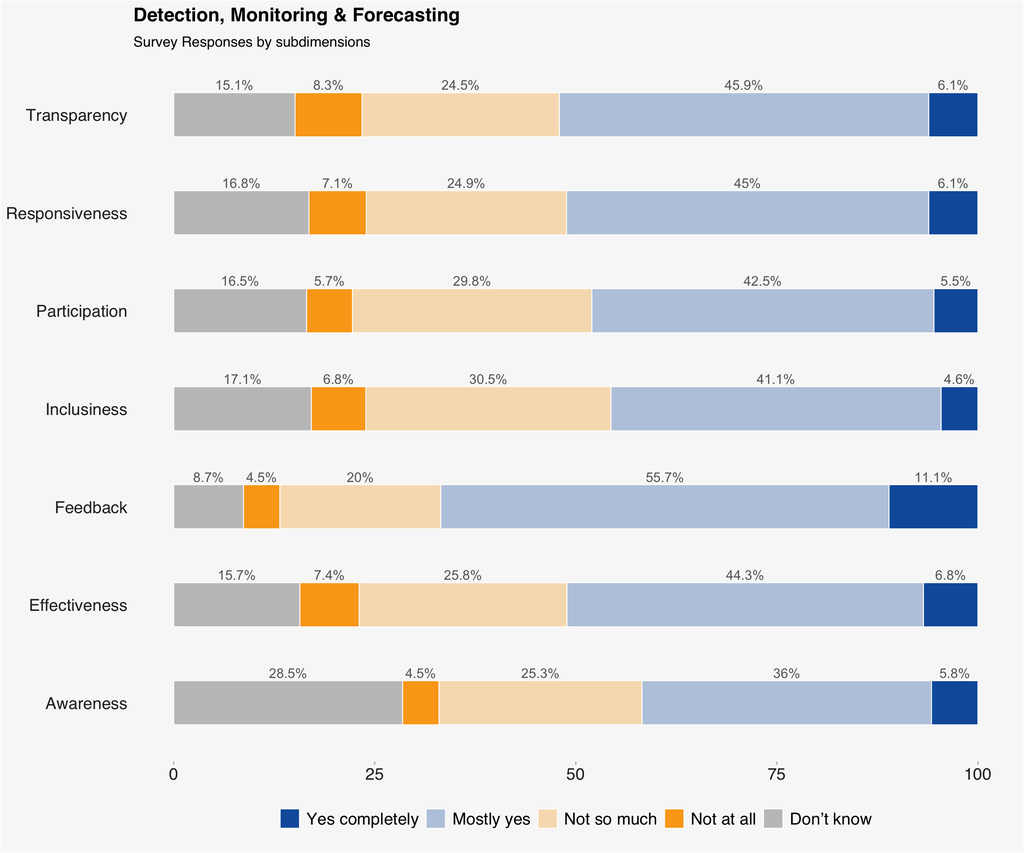

### Pillar 3

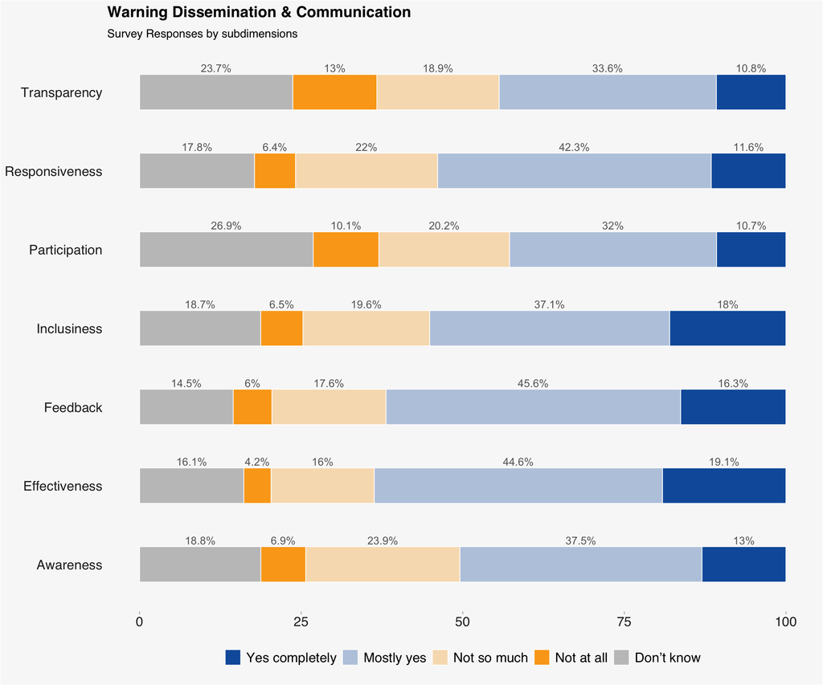

### Pillar 4

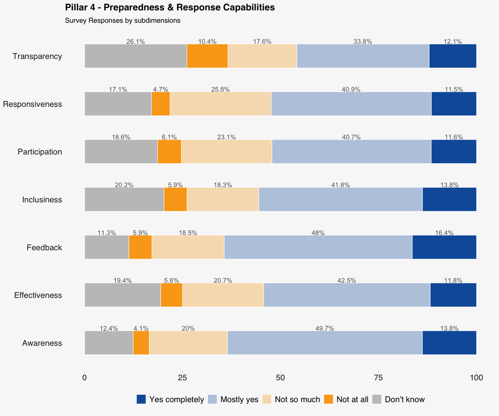

## Perception of Risk

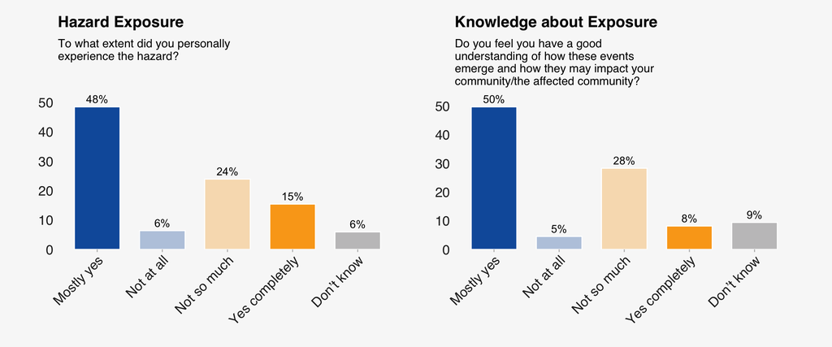

## Contextual questions

This section presents findings on community members’ experiences with and behaviors toward the Red Cross. These questions explore interactions, perceptions, and engagement patterns, offering insights into how the Red Cross is viewed and utilized within the community.

### Experiences

The survey shows that 39.7% of respondents reported having received aid or support, while 60.3% had not. Regarding early warning information, 39.8% reported receiving warnings from the Nepal Red Cross, compared with 56.4% who reported receiving other warnings. This suggests that respondents were more likely to receive warning information from sources other than the Nepal Red Cross.

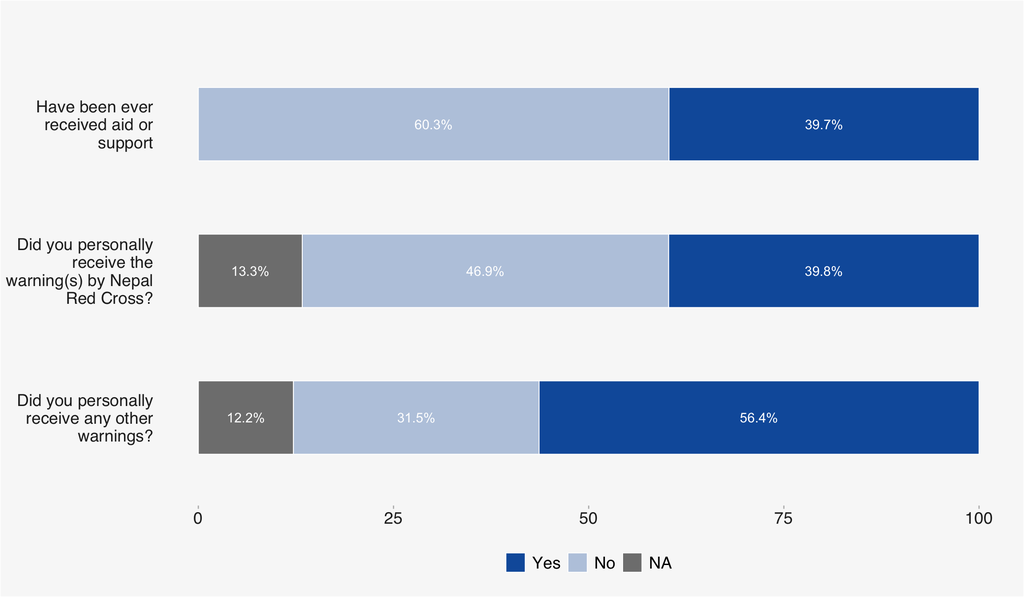

### Trust and EWS

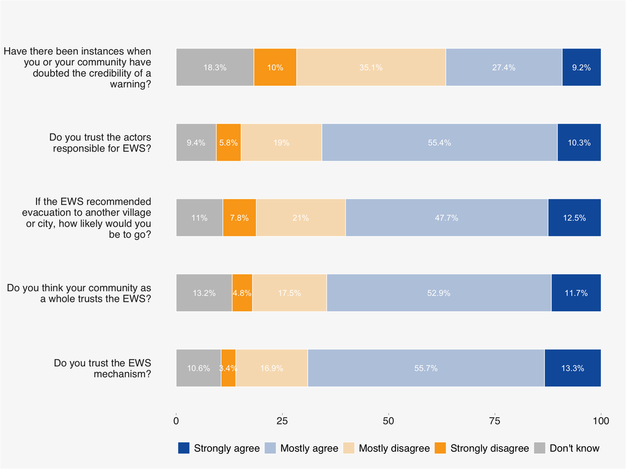

### Others Questions

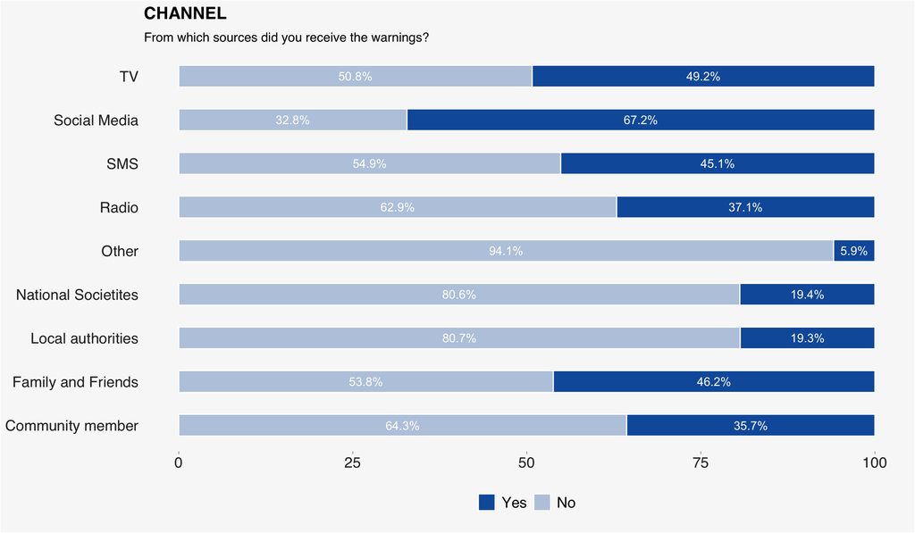

# Score

This score is derived from responses to questions that assess perceptions of competencies and values, providing a comprehensive measure of trust. A higher score indicates stronger trust, suggesting that community members believe their needs are being addressed and their values are respected. *Learn more about scoring method: Methods*

## Overall Score

The results show moderate to relatively strong performance across the four dimensions of the early warning system.

- Preparedness & Response Capabilities (Pillar 4) received the highest overall score (5.92), followed by Warning Dissemination & Communication (Pillar 3) (5.86).
- Disaster Risk Knowledge (Pillar 1) scored 5.48, while Detection, Monitoring and Forecasting (Pillar 2) had the lowest overall score (5.35).
- Feedback and effectiveness generally received stronger ratings across dimensions.
- Participation and transparency tended to score comparatively lower, indicating areas for improvement.

*Learn more about weighting process: Weighting*

### Scores by Pillar

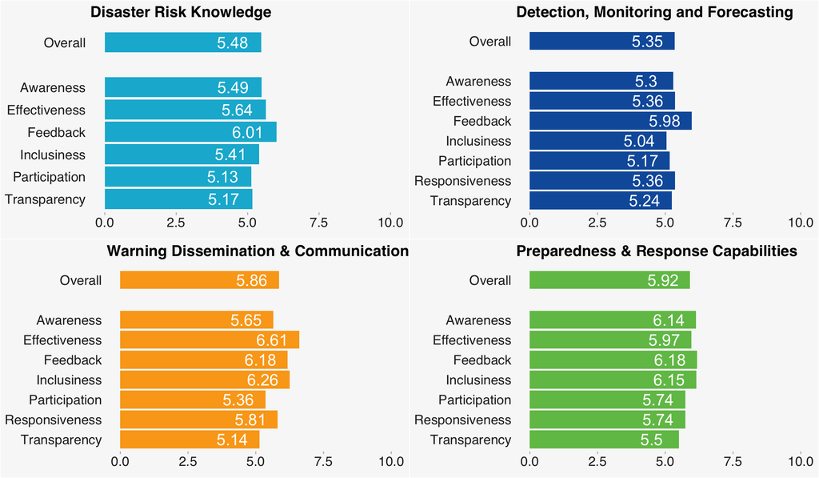

### Combined Pillar Scores

This chart presents the scores of key subdimensions across the four pillars:

- Feedback received the highest combined score (6.09), followed by Effectiveness (5.90) and Inclusiveness (5.71).
- Participation (5.35) and Transparency (5.26) received the lowest scores, indicating potential areas for improvement.

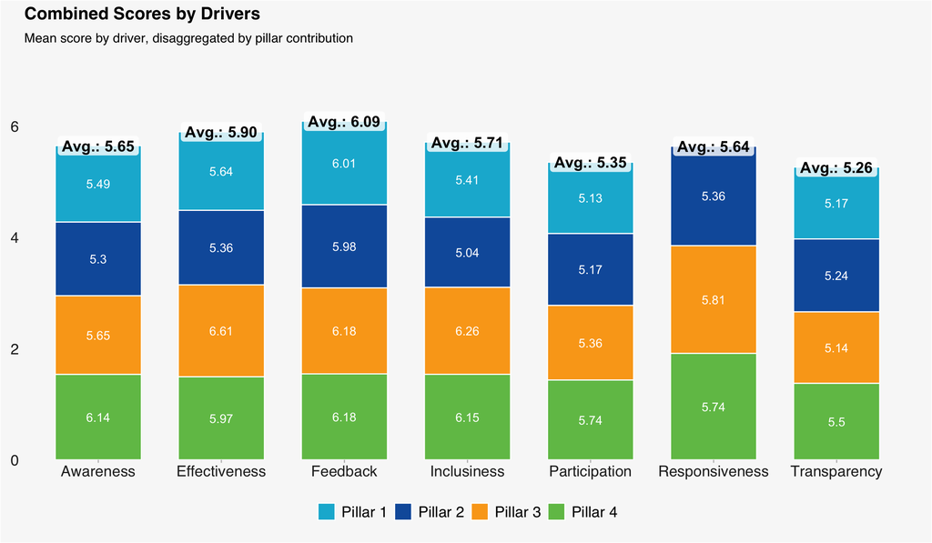

## Score by factors

This chart compares scores across different demographic and contextual groups.

*Distribution of mean scores for values and competencies per demographic questions*

### Pillars 1 & 2

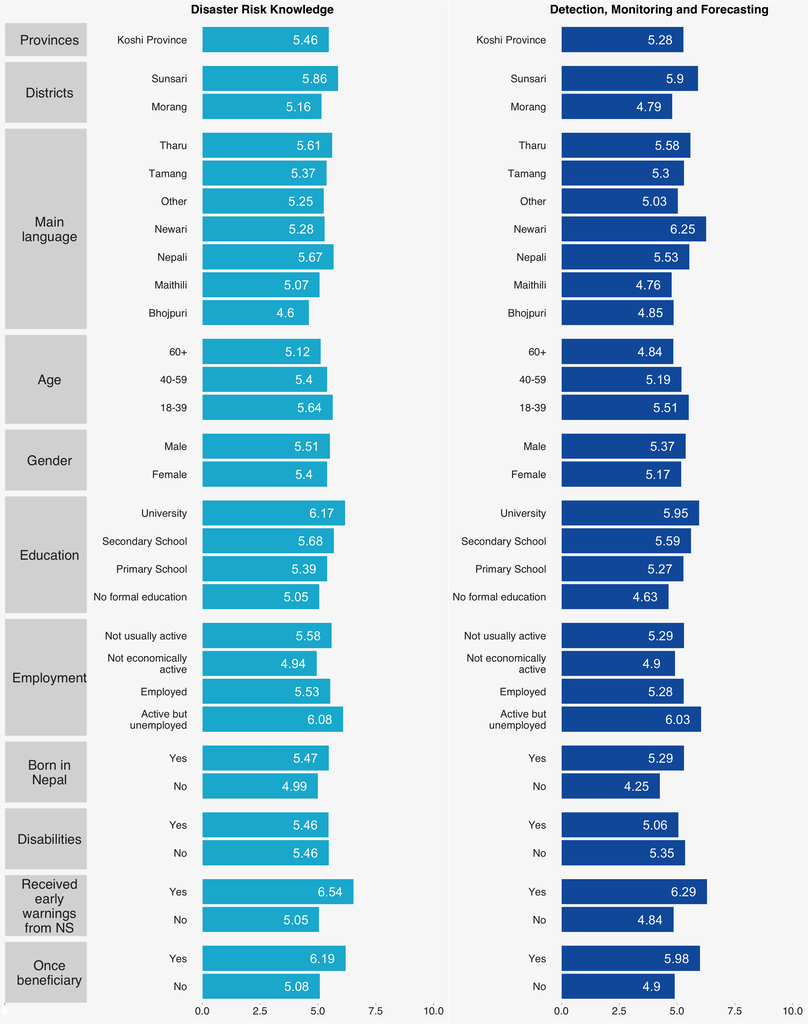

### Pillars 3 & 4

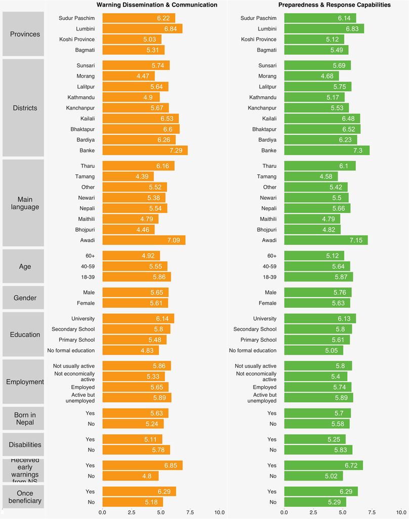

## Score by respondent profile

This chart compares scores across key dimensions by respondents’ level of engagement with Nepal Red Cross activities, including receipt of early warnings and previous beneficiary status.

### Pillars 1 & 2

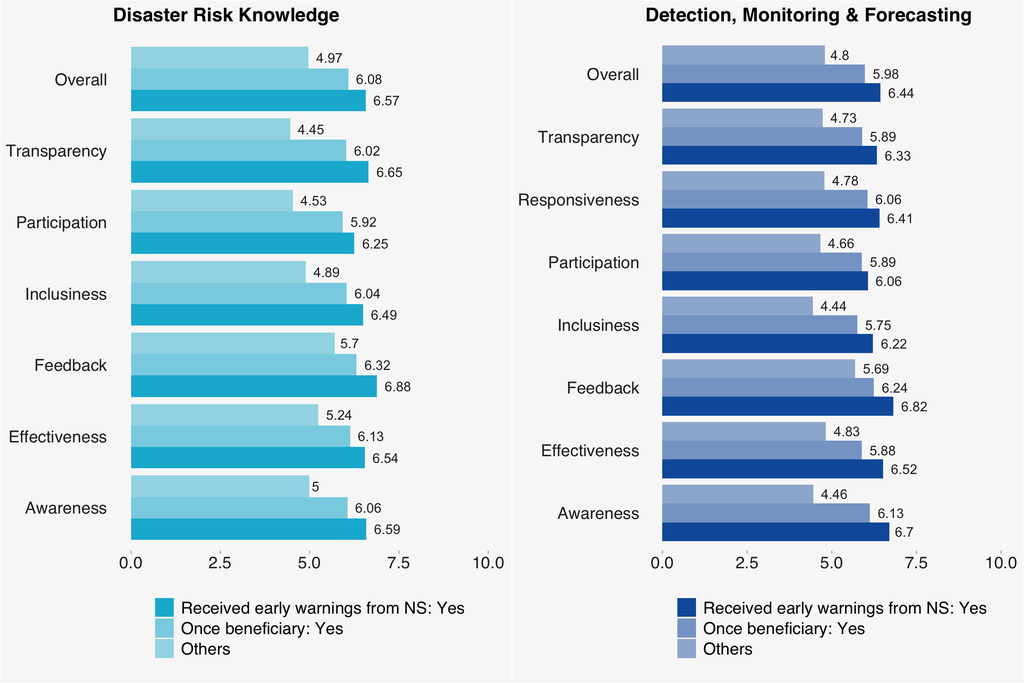

### Pillars 3 & 4

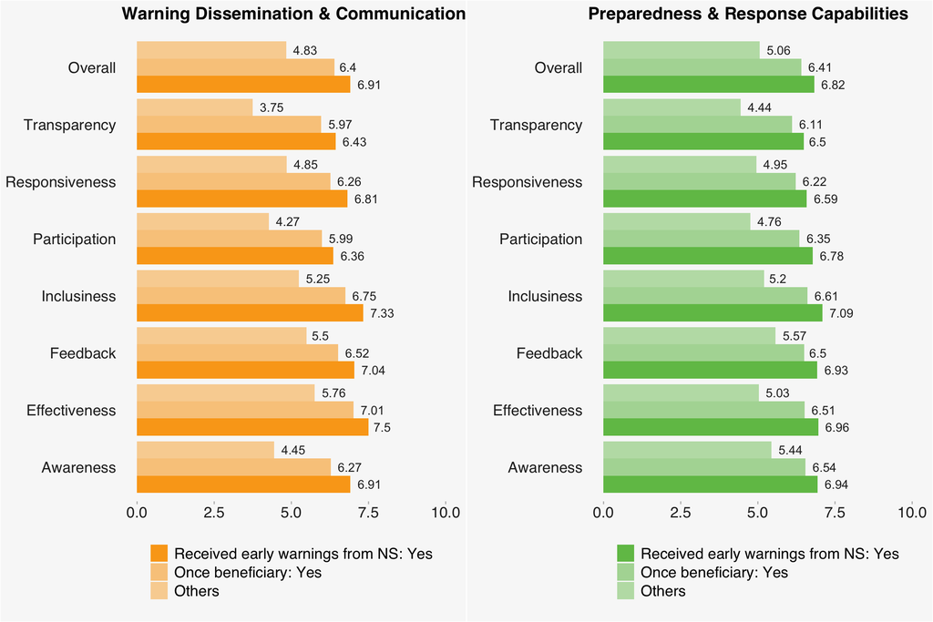

# Methods and Metrics

## Methods

**Scoring methodology**

To determine the score, we employ the following method:

1. Survey Structure The CTI – Early Warning and Anticipation module organizes all questions according to the four pillars of the Early Warning for All (EW4All) initiative:
- Disaster Risk Knowledge
- Detection, Monitoring and Forecasting
- Warning, Dissemination and Communication
- Preparedness and Response Capacity

Each pillar includes several sub-dimensions designed to assess different aspects of early warning system implementation.

2. Sub-Dimension Scoring

   Each sub-dimension comprises several survey items (questions).Respondents answer on a Likert-type scale (1 to 4 - Don’t not is excluded). For each sub-dimension:

   *Sub-dimension Score = ∑ (Weighted Response Scores) / Number of Items*

If weights are not empirically derived, equal weighting is typically applied to each item.

3. Pillar Scoring

Subsequent to the calculation of all sub-dimension scores, the score for each pillar is derived as the arithmetic mean of their respective sub-dimension scores.

For pillar (1 to i)

- *Pillar i Score = ∑(Sub-dimension Scores for Pillar i) /𝑛*

where 𝑛 is the number of sub-dimensions in each category.

4. Overall Scoring

   The final Community Trust Index score is the arithmetic mean of the Pillar scores available:
- *CTI Score = ∑(Pillar i Score)/N*

where N is the number of pillars.

## Metrics

### Gender

Respondents by Gender

| Gender | Total Respondents | Percentage (%) |
| --- | --- | --- |
| Female | 2434 | 49.1 |
| Male | 2519 | 50.8 |
| Other or did not answer | 5 | 0.1 |
| Total | 4958 | 100.0 |

### Age

Respondents by Age Group

| Age Group | Total Respondents | Percentage (%) |
| --- | --- | --- |
| 18-39 | 2537 | 51.2 |
| 40-59 | 1765 | 35.6 |
| 60+ | 656 | 13.2 |
| Total | 4958 | 100.0 |

### Geographic

Respondents by District and Province

| Province | District | Total Respondents | Percentage (%) |
| --- | --- | --- | --- |
| Bagmati | Kathmandu | 1051 | 65.9 |
| Bagmati | Lalitpur | 307 | 19.2 |
| Bagmati | Bhaktapur | 238 | 14.9 |
| Bagmati | TOTAL | 1596 | 100.0 |
| Koshi Province | Morang | 952 | 56.6 |
| Koshi Province | Sunsari | 731 | 43.4 |
| Koshi Province | TOTAL | 1683 | 100.0 |
| Lumbini | Banke | 412 | 56.4 |
| Lumbini | Bardiya | 319 | 43.6 |
| Lumbini | TOTAL | 731 | 100.0 |
| Sudur Paschim | Kailali | 607 | 64.0 |
| Sudur Paschim | Kanchanpur | 341 | 36.0 |
| Sudur Paschim | TOTAL | 948 | 100.0 |

### Relationship with RC

Respondents by relationship with RC

| Profile | Total Respondents |
| --- | --- |
| Received early warnings from NS: Yes | 1971 |
| Once beneficiary: Yes | 1969 |

## Weighting

**Weighting vs. unweighting**

To correct demographic deviations from the overall population, we applied a technique called raking. This method adjusts results based on variables such as age, gender, province, education level, and geographic (urban/rural) to align the sample with the population distribution. Data sources included the **2021 Nepal Population and Housing Census** (Central Bureau of Statistics, https://censusnepal.cbs.gov.np/Home/Index/EN).

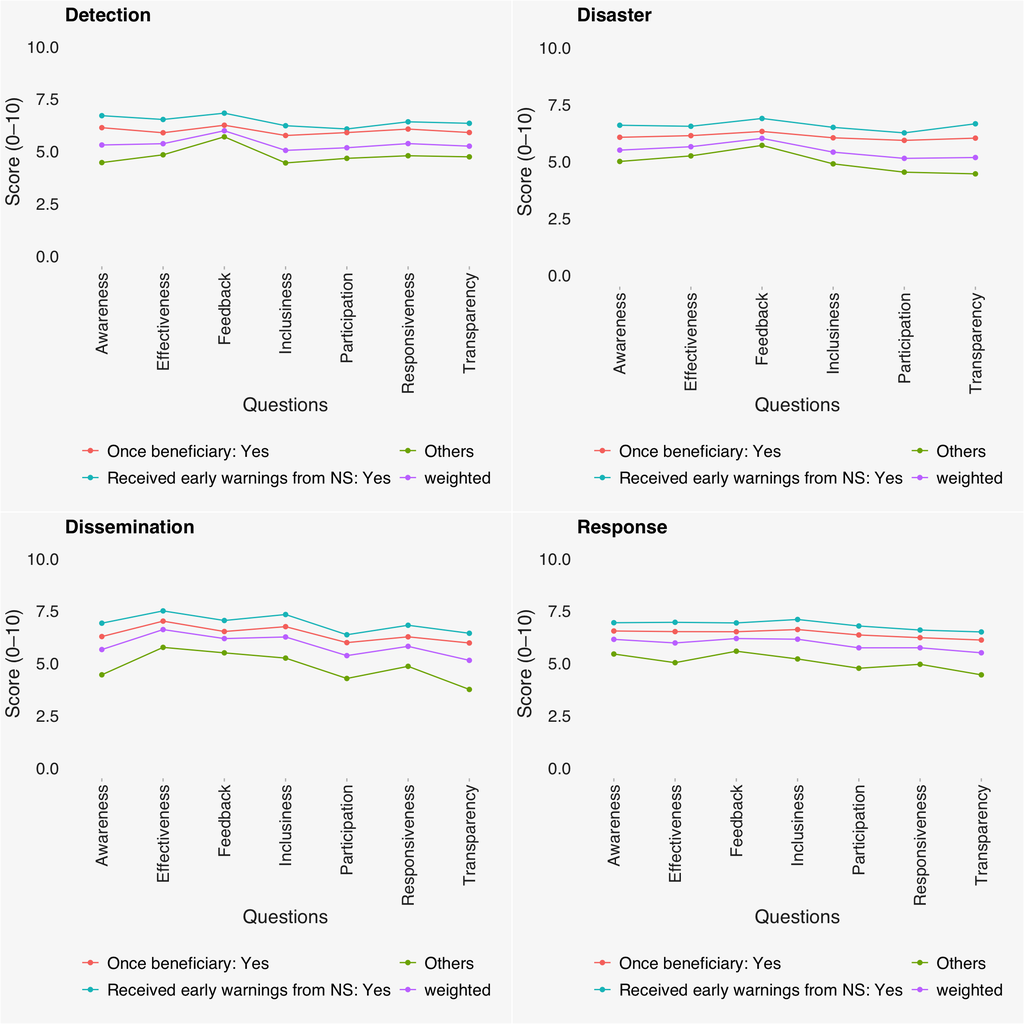

The weighted results are broadly consistent with the unweighted findings, with only small variations across dimensions. Across the four pillars, the overall patterns remain largely unchanged, with stronger performance generally observed in effectiveness, feedback, and inclusiveness, while participatio tends to score relatively lower. Differences between weighted and unweighted results are modest, indicating that weighting slightly adjusts scores but does not substantially alter the overall performance patterns or key findings.

## Drivers Correlation

**Correlation matrix**

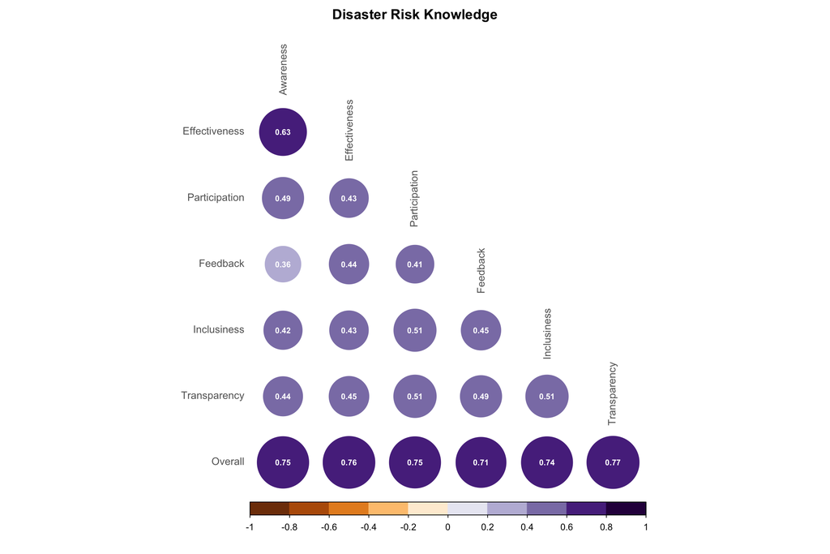

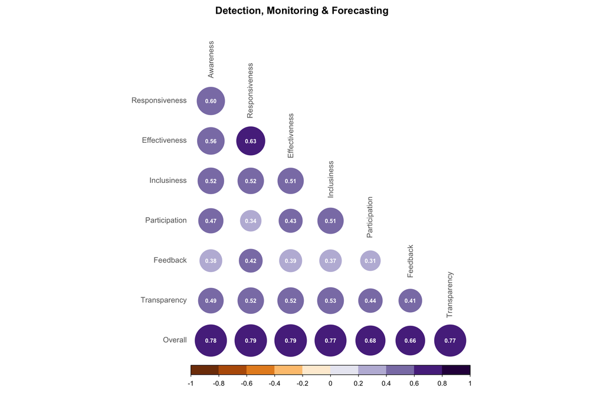

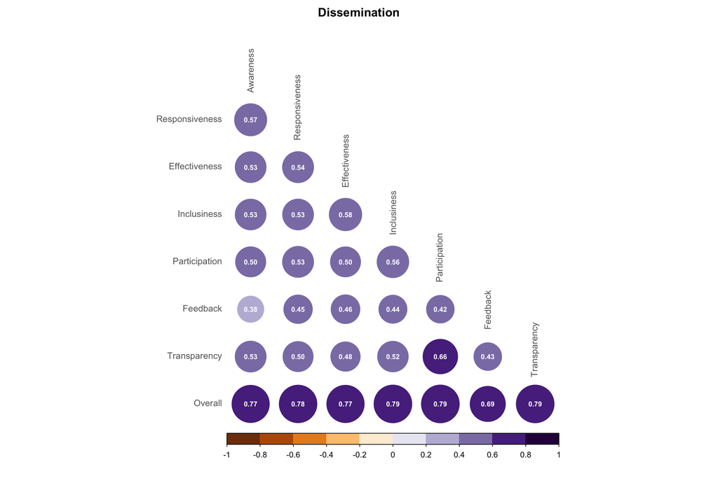

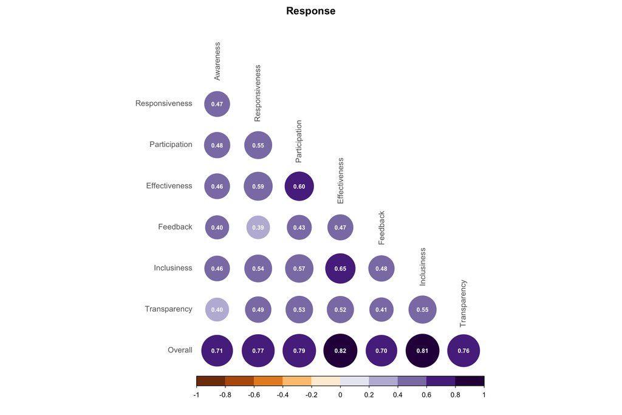

This chart shows the relationships between sub-dimensions across pillars, with the following key findings:

- Pillar 1: Moderate relationship between Awareness and Effectiveness
- Pillar 2: Moderate relationship between Responsiveness and Effectiveness
- Pillar 3: Moderate relationship between Participation and Transparency
- Pillar 4: Moderate relationship between Participation and Effectiveness, and Effectiveness and Inclusiveness

*How to read the correlation matrix:*

*1. Find the row and column*

- *Example: **Effectiveness × Inclusiveness = 0.65***
- *That means these two dimensions have a moderately strong positive relationship.*

*2. Read the number inside the circle*

- *Values range from **–1 to +1***
- *Interpretation:*

| Value | Meaning |
| --- | --- |
| 0.00 | No relationship |
| 0.10–0.30 | Weak |
| 0.30–0.50 | Mild |
| 0.50–0.70 | Moderate |
| 0.70–1.00 | Strong |
| Negative values | Variables move in opposite directions |

## Significance testing

**Significance testing**

When testing for significant differences between groups, a t-test was used to compare mean scores across dissemination and response questions. The table summarizes whether differences between People received support, people receved warnings, and others are statistically significant.

the results suggest strong alignment across most dimensions, particularly for Dissemination and Response, while greater variation is observed in some drivers within Disaster Risk Knowledge and Detection, Monitoring & Forecasting, especially for participation, inclusiveness, and responsiveness.

| Pillar | Drivers | Received early warnings from NS: Yes-Once beneficiary: Yes |
| --- | --- | --- |
| Disaster | Awareness | Yes |
| Disaster | Effectiveness | Yes |
| Disaster | Participation | No |
| Disaster | Feedback | Yes |
| Disaster | Inclusiness | No |
| Disaster | Transparency | Yes |
| Detection | Awareness | Yes |
| Detection | Responsiveness | No |
| Detection | Effectiveness | Yes |
| Detection | Inclusiness | No |
| Detection | Participation | No |
| Detection | Feedback | Yes |
| Detection | Transparency | Yes |
| Dissemination | Awareness | Yes |
| Dissemination | Responsiveness | Yes |
| Dissemination | Effectiveness | Yes |
| Dissemination | Inclusiness | Yes |
| Dissemination | Participation | Yes |
| Dissemination | Feedback | Yes |
| Dissemination | Transparency | Yes |
| Response | Awareness | Yes |
| Response | Responsiveness | Yes |
| Response | Participation | Yes |
| Response | Effectiveness | Yes |
| Response | Feedback | Yes |
| Response | Inclusiness | Yes |
| Response | Transparency | Yes |

# Download

Download Summary Excel File